# Captura-recaptura espacial con aclareo aleatorio (rtSCR)

José Jiménez (CSIC-IREC) email: jose.jimenez@csic.es

04/8/2022

## Introducción

En los modelos SCR originales (Royle et al., 2014) se usan sólo los eventos con identificación. Los **eventos sin identificación** se descartan. Recientemente se ha desarrollado un modelo (Jiménez et al., 2021) que permite hacer uso también de estos eventos sin identificación. Se basa en considerar que la identificación es un proceso aleatorio, en el cual un mismo animal puede aparecer en un evento como identificado, y en otro como no identificado, y mediante una aproximación mecanicista, el modelo rtSCR asigna las identidades a los eventos no identificados.

Hay que tener en cuenta que es un modelo que tiene algunas limitaciones a considerar: 1) sólo va a funcionar realmente bien en situaciones de baja densidad, y con bajo solapamiento de las áreas de campeo de los individuos, 2) Las mejoras más relevantes las vamos a obtener en los casos en que el porcentaje de identificados es bajo, y 3) es un modelo que necesita muchas iteraciones para alcanzar la convergencia, y por tanto es muy costoso computacionalmente. Vamos a ejecutar estos modelos usando $R$ (R Core Team, 2022) y Nimble (De Valpine et al., 2017). En este caso no es posible usar otro software MCMC, ya que se basa fundamentalmente en un muestreador Metropolis-Hastings creado para Nimble.

Recomiendo repetir el análisis que se ejecuta aquí, cambiando los valores de $set.seed()$ que controlan la aleatoriedad de las simulaciones. Tened en cuenta que la duración de la ejecución del modelo rtSCR tardará alrededor de 4 horas.

## Simulación de datos

Vamos a simular datos en $R$ y a ejecutar el modelo rtSCR. Para generar los datos simulados vamos a cargar varios paquetes de $R$ y un conjunto de funciones que he compilado y modificado para ser utilizadas aquí.

```r
setwd('C:/Users/Administrator/OneDrive - Universidad de Castilla-La Mancha/00 CURSOS/28 Curso Mexico')
library(nimble)
library(coda)
library(lattice)
library(scrbook)
library(MCMCvis)
library(mcmcOutput)
library(nimble)
source("SCR_functions.R")
```

Simulador de datos:

```r
SimSCR0<-function (N = 100, K = 5, lam0 = 0.35, sigma = 0.5, discard0 = TRUE,
 tel=2, n.locs=50, rnd = 2013) {
  set.seed(rnd)
  traplocs <- cbind(sort(rep(1:12, 12)), rep(1:12, 12))
  Dmat <- e2dist(traplocs, traplocs)
  ntraps <- nrow(traplocs)
  buffer <- 1.25
  Xl <- min(traplocs[, 1] - buffer)
  Xu <- max(traplocs[, 1] + buffer)
  Yl <- min(traplocs[, 2] - buffer)
  Yu <- max(traplocs[, 2] + buffer)
  sx <- runif(N, Xl, Xu)
  sy <- runif(N, Yl, Yu)
  S <- cbind(sx, sy)
  D <- e2dist(S, traplocs)
  lam <- lam0 * exp(-(D * D)/(2 * sigma * sigma))
  plot(traplocs, xlim=c(Xl,Xu), ylim=c(Yl,Yu), pch="+")
  points(S, col="blue", pch=16)
  Y <- array(NA, dim = c(N, ntraps, K))
  for (i in 1:nrow(Y)) {
    for (j in 1:ntraps) {
      Y[i, j, 1:K] <- rpois(K, lam[i, j])
    }
  }
  if (discard0) {
    Y2d <- apply(Y, c(1, 2), sum)
    ncaps <- apply(Y2d, 1, sum)
    Y <- Y[ncaps > 0, , ]
  }

  if (tel > 0) {
    itel <- sort(sample(1:tel, tel, replace = F))
    locs <- list()
    for (i in 1:tel) {
      lx <- rnorm(n.locs, S[itel[i], 1], sigma)
      ly <- rnorm(n.locs, S[itel[i], 2], sigma)
      locs[[i]] <- cbind(lx, ly)
    }
  }
  else {
    locs <- NULL
    itel <- NULL
  }

  list(Y = Y, traplocs = traplocs, xlim = c(Xl, Xu), ylim = c(Yl, Yu), N = N,
       lam0 = lam0, sigma = sigma, K = K, tel = tel, locs=locs, n.locs=n.locs, S=S)
}
```

Vamos a generar nuestros datos. Los veremos gráficamente:

```r
## Simulación de los datos
data <- SimSCR0(N=20, lam0=0.5, K=10, discard0=TRUE, sigma=0.5, tel=2, n.locs=50, rnd=1)
```

[figure not shown]

```r
# Centros de actividad
S<-data$S
y<- data$Y  # todos los historiales de captura

# Trampas
X<- data$traplocs
X<-matrix(X, ncol=2)
J<-nrow(X) # número de trampa
K<-data$K  # número de ocasiones de muestreo

(nind <- nrow(apply(y, c(1,2), sum))) # Número de individuos detectados
```

```
## [1] 18
```

```r
set.seed(1960)
## Simulación de identificación de los individuos
id.prob <- 0.2  # ID rate
y.id1<-array(0,c(nind, J, K))
for(i in 1:nind){
  for(j in 1:J){
    for(k in 1:K){
      y.id1[i,j,k]<-rbinom(prob=id.prob, 1, y[i,j,k])
    }
  }
}

sum(y.id1) # eventos con identificación (ID)
```

```
## [1] 19
```

```r
y.id<-y.id1[apply(y.id1,1,sum)>0,,]       # Descartamos las historias que no tienen ID
(nind2<-nrow(apply(y.id, c(1,3), sum)))   # Número de individuos identificados
```

```
## [1] 11
```

```r
M <- 80                                   # Aumentado de datos
yaug<-array(0,c(M,J,K))
yaug[1:nind2,,]<-y.id
sum(yaug)                                 # Eventos con identificación
```

```
## [1] 19
```

```r
# Frecuencias de capturas sin identificación
nnid<-apply(y,c(2,3),sum)-apply(y.id, c(2,3), sum)
sum(nnid)                                 # Eventos sin identificación
```

```
## [1] 113
```

```r
nnidd<-apply(nnid,1,sum)

# Espacio de estados
xlims <- data$xlim
ylims <- data$ylim
A <- diff(xlims)*diff(ylims)   # Tamaño del espacio de estados
```

Vamos a plotear las capturas y crear el spiderplot. En el spiderplot representamos las trampas o detectores (en este caso utilizamos cruces; en la versión standard usando *scrbook* son puntos). Con puntos en azul (pequeños), representamos los individuos de la poblacion. Los círculos en azul transparente son las observaciones con identificación, y tienen un tamaño proporcional al número de observaciones. Los círculos en color anaranjado son las observaciones sin identificación, y al igual que los anteriores, tienen un tamaño proporcional al número de observaciones. Los puntos en rojo (grandes) son promedios de las detecciones de cada individuo en el total de cámaras donde se ha detectado, y vienen a ser una aproximación naïve de los centros de actividad. Las líneas en negro representan el movimiento del animal entre diferentes trampas (que lo denominamos recapturas espaciales).

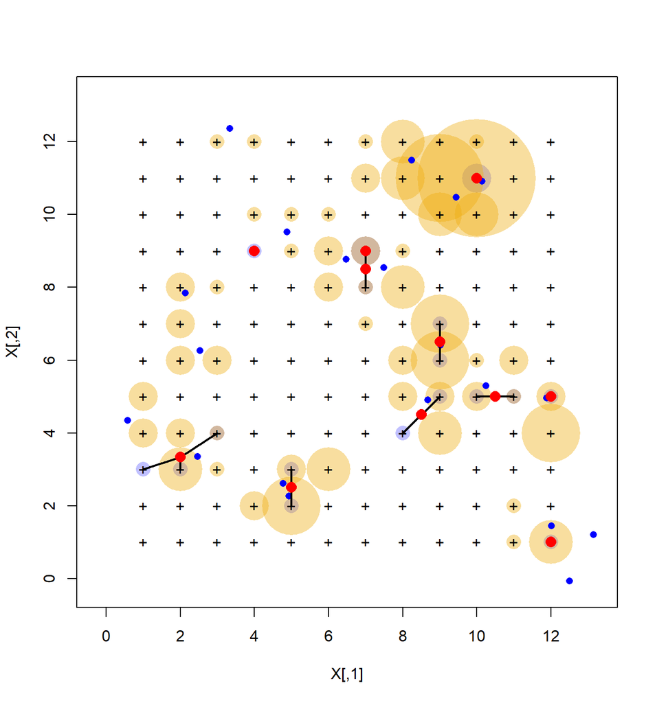

```r
# Ploteado de capturas
plot(X, pch="+",cex=1, xlim=xlims, ylim=ylims, main="", type="n")
tot<-apply(y.id, 2,sum)
## Individuos identificados
symbols(X, circles=tot/5, inches=F, bg="#0000FF3F",  fg=NULL, add=T)
## Individuos sin identificación
nID<-as.numeric(apply(nnid,1,sum))
symbols(X, circles=nID/5, inches=F,bg="#EEAD0E66",fg=NULL, add=T)
points(X, pch="+", cex=1)
points(data$S, col="blue", pch=16)
spiderplot.Over(y.id, X, buffer=0,lwd=2)
```

## Código rtSCR

```r
#### Modelo
NimModel <- nimbleCode({

  lam0 ~ dunif(0,5)
  sig ~ dunif(0,5)
  sig2 <- 2*sig^2
  psi ~ dbeta(1,1)
  id.prob ~ dunif(0,1)

  for(i in 1:M) {
    s[i,1] ~ dunif(xlim[1], xlim[2])
    s[i,2] ~ dunif(ylim[1], ylim[2])
    z[i] ~ dbern(psi)
    d2[i,1:J] <- (s[i,1]-x[1:J,1])^2 + (s[i,2]-x[1:J,2])^2
    lam[i,1:J] <- lam0*exp(-d2[i,1:J]/sig2)*z[i]

    for(j in 1:J) {
      # Historias completas de encuentro
      y.full[i,j] ~ dpois(lam[i,j]*K)
      # Historias de encuentros aleatorios con identificación
      y.obs[i,j] ~ dbin(id.prob, y.full[i,j])
    }
  }

  # nnid (no identificados) se va a usar el el muestreador IDSampler

  N <- sum(z[1:M])
  D <- N/A
})
```

## Muestreador personalizado Metropolis-Hastings

Es un muestreador para actualizar conjuntamente *y.un[1:M,j]* de manera que ponemos en cada paso del muestreo la condición de que sumen *n[j]*.

```r
IDSampler <- nimbleFunction(
  contains = sampler_BASE,
  setup = function(model, mvSaved, target, control) {
    # Definimos los componentes a usar
    nnidd<-control$nnidd
    j<-control$j
    M<-control$M
    calcNodes <- model$getDependencies(target)
  },

run = function() {
  lam.curr <- model$lam[1:M,j] # Conteos esperados de individuos por trampa

  #Muestrea y[1:M,j] reasignando n[j] usando el condicional completo
  switch.probs <- lam.curr[1:M]/sum(lam.curr[1:M])

  #propone nuevas identificaciones para nnid[j,k]
  y.latent.curr <- model$y.full[1:M,j]- model$y.obs[1:M,j]
  y.latent.prop <- rmulti(1, nnidd, switch.probs[1:M])
  model$y.full[1:M,j] <<-  model$y.obs[1:M,j] + y.latent.prop

  # modelo inicial logProb
  model_lp_initial <- model$getLogProb(calcNodes)

  # modelo propuesto logProb
  model_lp_proposed <- model$calculate(calcNodes)

  # Relación log-Metropolis-Hastings
  log_MH_ratio <- (model_lp_proposed + dmulti(y.latent.curr, nnidd, switch.probs, log=TRUE)) -
                  (model_lp_initial + dmulti(y.latent.prop,  nnidd, switch.probs, log=TRUE))

  # Paso Metrópolis-Hastings
  accept <- decide(log_MH_ratio)
    if(accept) {
      copy(from = model, to = mvSaved, row = 1, nodes = calcNodes, logProb = TRUE)
    } else {
      copy(from = mvSaved, to = model, row = 1, nodes = calcNodes, logProb = TRUE)
    }
  },
  methods = list( reset = function () {} )
)
```

## Preparamos constantes, datos e inicios

Preparamos las constantes:

```r
str(constants <- list(nnid=nnid,      # eventos sin identificación
                      J=J,            # nº trampas
                      M=M,            # aumentado de datos
                      K=K,            # nº ocasiones
                      A=A))           # tamaño del espacio de estados
```

```
## List of 5
##  $ nnid: num [1:144, 1:10] 0 0 0 0 0 0 0 0 0 0 ...
##  $ J   : int 144
##  $ M   : num 80
##  $ K   : num 10
##  $ A   : num 182
```

… los datos…

```r
yred<-apply(yaug,c(1,2),sum)
str(data    <-   list(y.obs=yred,     # historias con identificación
                      xlim=xlims,     # límite X del espacio de estados
                      ylim=ylims,     # límite Y del espacio de estados
                      x=X))           # coordenadas de las trampas
```

```
## List of 4
##  $ y.obs: num [1:80, 1:144] 0 0 0 0 0 0 0 0 0 0 ...
##  $ xlim : num [1:2] -0.25 13.25
##  $ ylim : num [1:2] -0.25 13.25
##  $ x    : int [1:144, 1:2] 1 1 1 1 1 1 1 1 1 1 ...
```

… y los inicios. Los valores iniciales en este código en Nimble deben ser cuidadosamente adaptados para asegurar que todos los nodos, particularmente para el latente $y.full$, comiencen con valores iniciales razonables. Cualquier error aquí podría invalidar los resultados:

```r
ys<-apply(yaug,c(1,2),sum)
s.start <- cbind(runif(M, xlims[1], xlims[2]), runif(M, ylims[1], ylims[2]))
d <- e2dist(s.start[1:M,], X)
lam0s<- runif(1,0,1)
sigs <- runif(1,0,1)

lam <- lam0s * exp( -(d^2)/(2 * sigs^2))

# Creamos un inicio de la historia completa
yi <- array(0, c(M, J, K))
for (j in 1:J) {
  for (k in 1:K) {
    if (nnid[j, k] > 0) {
      probs <- lam[ ,j]
      probs <- probs / sum(probs)
      latent.id <- sample(1:M, nnid[j,k], prob = probs, replace = FALSE)
      yi[latent.id , j, k] <- 1
    }
  } # k
}   # j

yis<-apply(yi,c(1,2),sum) + apply(yaug,c(1,2),sum)
zst<-apply(yis, 1, sum); zst[zst>0]<-1
id.prob.s<-sum(yaug)/(sum(yaug)+sum(nnid))

str(inits   <-   list(z=zst,             # inicios de z
                      s=s.start,         # inicios de s
                      lam0=lam0s,        # ratio base de detección
                      sig=sigs,          # parámetro de movimiento
                      id.prob=id.prob.s, # ratio de identificación
                      psi=runif(1,0,1),  # parámetro de aumentado de datos
                      y.full=yis))       # historias completas (latente)
```

```
## List of 7
##  $ z      : num [1:80] 1 1 1 1 1 1 1 1 1 1 ...
##  $ s      : num [1:80, 1:2] 5.43 5.15 12.68 5.47 3.73 ...
##  $ lam0   : num 0.253
##  $ sig    : num 0.648
##  $ id.prob: num 0.144
##  $ psi    : num 0.904
##  $ y.full : num [1:80, 1:144] 0 0 0 0 0 0 0 0 0 0 ...
```

Parámetros que vamos a monitorizar

```r
params <- c('psi', 'lam0', 'sig', 'N', 'D', 'id.prob')
```

## Compilamos y ejecutamos:

```r
start.time<-Sys.time()
Rmodel <- nimbleModel(code=NimModel,
                      constants=constants,
                      data=data,
                      inits=inits,
                      check=FALSE)
```

```
## Defining model
```

```
## Building model
```

```
## Setting data and initial values
```

```
## Running calculate on model
##   [Note] Any error reports that follow may simply reflect missing values in model variables.
```

```
## Checking model sizes and dimensions
```

```r
Cmodel <- compileNimble(Rmodel)
```

```
## Compiling
##   [Note] This may take a minute.
##   [Note] Use 'showCompilerOutput = TRUE' to see C++ compilation details.
```

```r
conf <- configureMCMC(Rmodel,monitors=params, thin=10, useConjugacy = TRUE)
```

```
## ===== Monitors =====
## thin = 10: D, id.prob, lam0, N, psi, sig
## ===== Samplers =====
## slice sampler (11520)
##   - y.full[]  (11520 elements)
## RW sampler (163)
##   - lam0
##   - sig
##   - id.prob
##   - s[]  (160 elements)
## conjugate sampler (1)
##   - psi
## binary sampler (80)
##   - z[]  (80 elements)
```

```r
#### -- Hemos cargado antes el muestreador personalizado tras el modelo  -- ####
# reemplazar con un nuevo muestreador para *y* (muestra sin reemplazo con suma
# resringida a n[j,k])
conf$removeSampler("y.full")
for(j in 1:J){
  conf$addSampler(target = paste(paste("y.full[1:",M,", ",j,"]"), sep=""),
                  type = 'IDSampler',
                  control = list(nnidd = nnidd[j], j=j, M=M),
                  silent = TRUE)
}

# Muestreamos simultáneamente los nodos s[,1] y s[,2]
ACnodes <- paste0("s[", 1:constants$M, ", 1:2]")
for(node in ACnodes) {
  conf$addSampler(target = node,
                  type = "AF_slice",
                  control = list(adaptScaleOnly = TRUE),
                  silent = TRUE)
}


Rmcmc <- buildMCMC(conf)
Cmcmc <- compileNimble(Rmcmc, project = Rmodel)
```

```
## Compiling
##   [Note] This may take a minute.
##   [Note] Use 'showCompilerOutput = TRUE' to see C++ compilation details.
```

```r
# start.time2<-Sys.time()  # Tarda aproximademente 4h la ejecución
# outNim <- runMCMC(Cmcmc, niter = 500000, nburnin = 50000, nchains = 3,
#                  inits=inits, setSeed = TRUE, progressBar = TRUE,
#                  samplesAsCodaMCMC = TRUE)
# end.time<-Sys.time()
# end.time-start.time2 # tiempo de ejecución

# Cargo el resultado previamente calculado
load("outNim_RandomThinningSCR.RData")
```

## Resultados

Compararemos lo simulado con los valores posteriores, y así podemos tener una idea de que tal funciona nuestro modelo.

```r
summary(outNim)
```

```
##
## Iterations = 1:4500
## Thinning interval = 1
## Number of chains = 3
## Sample size per chain = 4500
##
## 1. Empirical mean and standard deviation for each variable,
##    plus standard error of the mean:
##
##            Mean      SD  Naive SE Time-series SE
## D        0.1028 0.01360 0.0001171      0.0004819
## N       18.7264 2.47935 0.0213389      0.0878181
## id.prob  0.1489 0.03060 0.0002634      0.0002634
## lam0     0.4002 0.06608 0.0005687      0.0008534
## psi      0.2404 0.05564 0.0004789      0.0011078
## sig      0.5926 0.04451 0.0003830      0.0009522
##
## 2. Quantiles for each variable:
##
##             2.5%      25%      50%     75%   97.5%
## D        0.08230  0.09328  0.09877  0.1097  0.1372
## N       15.00000 17.00000 18.00000 20.0000 25.0000
## id.prob  0.09443  0.12712  0.14711  0.1689  0.2132
## lam0     0.28154  0.35312  0.39709  0.4427  0.5394
## psi      0.14244  0.20096  0.23668  0.2756  0.3610
## sig      0.50695  0.56279  0.59141  0.6207  0.6827
```

## Chequeamos convergencia de las cadenas de Markov

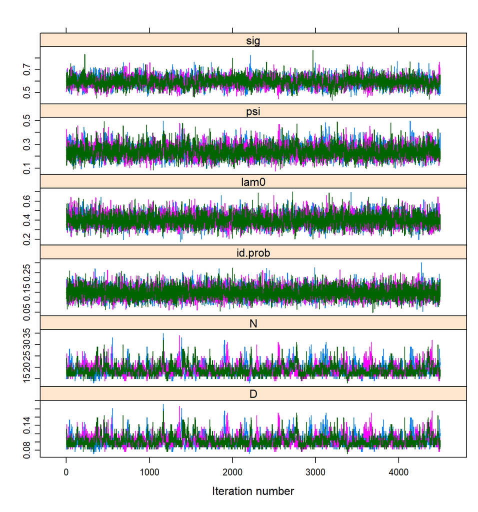

```r
#diagPlot(outNim[,c('N','D','p0','psi', 'sigma')])
xyplot(outNim)
```

## Referencias

De Valpine, P., Turek, D., Paciorek, C. J., Anderson-Bergman, D., Lang, T., & Bodik, R. (2017). Programming with models: writing statistical algorithms for general model structures with NIMBLE. *Journal of Computational and Graphical Statistics*, 26, 403–413.DOI:10.1080/10618600.2016.1172487

Jiménez, J., Augustine, B. C., Linden, D. W., Chandler, R. B., & Royle, J. A. (2021). Spatial capture–recapture with random thinning for unidentified encounters. *Ecology and Evolution, 11*(3), 1187–1198. doi:10.1002/ece3.7091

R Core Team. (2022). *R: A language and environment for statistical computing. R Foundation for Statistical Computing*. Vienna, Austria. Retrieved from https://www.r-project.org/.

Royle, J. A., Chandler, R. B., Sollmann, R., & Gardner, B. (2014). *Spatial capture-recapture*. Waltham, Massachusetts: Elsevier, Academic Press. doi:10.1016/B978-0-12-405939-9.00026-8